# Resolución tarea 2

Minor Solano Gutiérrez

10/10/2020

# Regresión escalonada

En el siguiente trabajo se realizará un ejemplo de Regresión escalonada

## Cargar la función replicar_reg_scal()

Esta función permite replicar la regresión escalonada (stepwise regression) usando simulaciones. La función devuelve la proporción de réplicas que produjeron al menos una variable con un efecto significativo (i. e. falsos positivos)

Argumentos: itr: numero de iteraciones o replicas (el valor por defecto es 100) nvars: numero de variables para representar (el valor por defecto es 50) n: número de observaciones en cada variable (el valor por defecto es 30) alpha = umbral para definir significancia estadística en los valores de p

```r
source("./scripts/replicar_reg_scal.R")
```

## Calculo con un alfa = 0.05

Definir significancia estadística en los valores de p = 0.05

### Calculo de la proporción de falsos positivos para 10 números de variables

```r
#números de variables = 10 (argumento nvars)

nvars10 <- c(10, 10, 10)


falsos_positivos10.1 <- replicar_reg_scal(itr = 100, n = 30, nvars = 10, alfa = 0.05)
falsos_positivos10.2 <- replicar_reg_scal(itr = 100, n = 30, nvars = 10, alfa = 0.05)
falsos_positivos10.3 <- replicar_reg_scal(itr = 100, n = 30, nvars = 10, alfa = 0.05)

falsos_positivos10 <- c(falsos_positivos10.1, falsos_positivos10.2, falsos_positivos10.3)
```

### Calculo de la proporción de falsos positivos para 20 números de variables

```r
#números de variables = 20 (argumento nvars)

nvars20 <- c(20, 20, 20)

falsos_positivos20.1 <- replicar_reg_scal(itr = 100, n = 30, nvars = 20, alfa = 0.05)
falsos_positivos20.2 <- replicar_reg_scal(itr = 100, n = 30, nvars = 20, alfa = 0.05)
falsos_positivos20.3 <- replicar_reg_scal(itr = 100, n = 30, nvars = 20, alfa = 0.05)

falsos_positivos20 <- c(falsos_positivos20.1, falsos_positivos20.2, falsos_positivos20.3)
```

### Calculo de la proporción de falsos positivos para 50 números de variables

```r
#números de variables = 50 (argumento nvars)

nvars50 <- c(50, 50, 50)

falsos_positivos50.1 <- replicar_reg_scal(itr = 100, n = 30, nvars = 50, alfa = 0.05)
falsos_positivos50.2 <- replicar_reg_scal(itr = 100, n = 30, nvars = 50, alfa = 0.05)
falsos_positivos50.3 <- replicar_reg_scal(itr = 100, n = 30, nvars = 50, alfa = 0.05)

falsos_positivos50 <- c(falsos_positivos50.1, falsos_positivos50.2, falsos_positivos50.3)
```

### Calculo de la proporción de falsos positivos para 100 números de variables

```r
#números de variables = 100 (argumento nvars)

nvars100 <- c(100, 100, 100)

falsos_positivos100.1 <- replicar_reg_scal(itr = 100, n = 30, nvars = 100, alfa = 0.05)
falsos_positivos100.2 <- replicar_reg_scal(itr = 100, n = 30, nvars = 100, alfa = 0.05)
falsos_positivos100.3 <- replicar_reg_scal(itr = 100, n = 30, nvars = 100, alfa = 0.05)

falsos_positivos100 <- c(falsos_positivos100.1, falsos_positivos100.2, falsos_positivos100.3)
```

### Figura comparativa entre número de variables y la proporción de falsos positivos.

En la siguiente figura observarán la relación entre el número de variables y la proporción de falsos positivos calculadas anteriormente

```r
nvars <- c(nvars10, nvars20, nvars50, nvars100)

falsos_positivos <- c(falsos_positivos10, falsos_positivos20, falsos_positivos50, falsos_positivos100)

relacion1 <- lm(falsos_positivos ~ nvars)
summary(relacion1)
```

```
##
## Call:
## lm(formula = falsos_positivos ~ nvars)
##
## Residuals:
##       Min        1Q    Median        3Q       Max
## -0.084524 -0.034524 -0.001871  0.027951  0.101599
##
## Coefficients:
##              Estimate Std. Error t value Pr(>|t|)
## (Intercept) 0.2060544  0.0267425   7.705 1.63e-05 ***
## nvars       0.0028469  0.0004691   6.069 0.000121 ***
## ---
## Signif. codes:  0 '***' 0.001 '**' 0.01 '*' 0.05 '.' 0.1 ' ' 1
##
## Residual standard error: 0.05687 on 10 degrees of freedom
## Multiple R-squared:  0.7865, Adjusted R-squared:  0.7651
## F-statistic: 36.83 on 1 and 10 DF,  p-value: 0.0001205
```

```r
eq <- substitute(italic(y) == a + b %.% italic(x)*","~~italic(r)^2~"="~r2,
                   list(a = format(unname(coef(relacion1)[1]), digits = 2),
                        b = format(unname(coef(relacion1)[2]), digits = 2),
                        r2 = format(summary(relacion1)$r.squared, digits = 3)))
as.character(as.expression(eq))
```

```
## [1] "italic(y) == \"0.21\" + \"0.0028\" %.% italic(x) * \",\" ~ ~italic(r)^2 ~ \"=\" ~ \"0.786\""
```

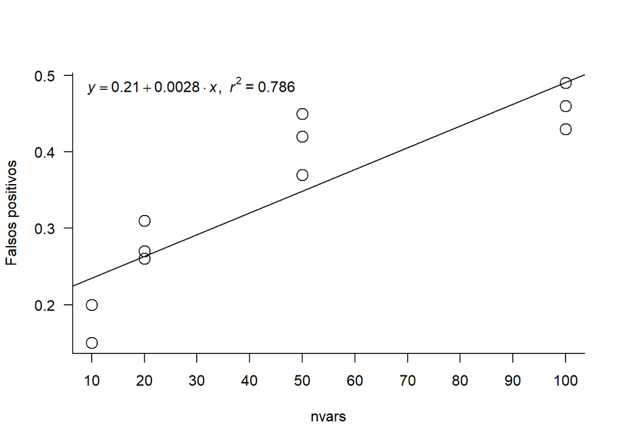

```r
par(bty='n')
plot(falsos_positivos ~ nvars, ylab = "Falsos positivos", xlab = expression(paste("nvars")),  cex = 1.75, axes = F, main = "")
axis(2, las = 1, seq(from = 0, to = 1, by = 0.1))
axis(1, seq(from = 0, to = 100, by = 10))
X1 <- grconvertX(0, "npc")
Y1 <- grconvertY(1, "npc")
legend(X1, Y1, bty = "n",
       cex = 1,legend = eq, border = T, x.intersp = 0.1, y.intersp = 0.3, horiz = T)
box(bty = "l")
abline(relacion1)
```

## Calculo con un alfa = 0.01

Definir significancia estadística en los valores de p = 0.01

### Calculo de la proporción de falsos positivos para 10 números de variables

```r
#números de variables = 10 (argumento nvars)

nvars10 <- c(10, 10, 10)

falsos_positivos10.1 <- replicar_reg_scal(itr = 100, n = 30, nvars = 10, alfa = 0.01)
falsos_positivos10.2 <- replicar_reg_scal(itr = 100, n = 30, nvars = 10, alfa = 0.01)
falsos_positivos10.3 <- replicar_reg_scal(itr = 100, n = 30, nvars = 10, alfa = 0.01)

falsos_positivos10 <- c(falsos_positivos10.1, falsos_positivos10.2, falsos_positivos10.3)
```

### Calculo de la proporción de falsos positivos para 20 números de variables

```r
#números de variables = 20 (argumento nvars)

nvars20 <- c(20, 20, 20)

falsos_positivos20.1 <- replicar_reg_scal(itr = 100, n = 30, nvars = 20, alfa = 0.01)
falsos_positivos20.2 <- replicar_reg_scal(itr = 100, n = 30, nvars = 20, alfa = 0.01)
falsos_positivos20.3 <- replicar_reg_scal(itr = 100, n = 30, nvars = 20, alfa = 0.01)

falsos_positivos20 <- c(falsos_positivos20.1, falsos_positivos20.2, falsos_positivos20.3)
```

### Calculo de la proporción de falsos positivos para 50 números de variables

```r
#números de variables = 50 (argumento nvars)

nvars50 <- c(50, 50, 50)

falsos_positivos50.1 <- replicar_reg_scal(itr = 100, n = 30, nvars = 50, alfa = 0.01)
falsos_positivos50.2 <- replicar_reg_scal(itr = 100, n = 30, nvars = 50, alfa = 0.01)
falsos_positivos50.3 <- replicar_reg_scal(itr = 100, n = 30, nvars = 50, alfa = 0.01)

falsos_positivos50 <- c(falsos_positivos50.1, falsos_positivos50.2, falsos_positivos50.3)
```

### Calculo de la proporción de falsos positivos para 100 números de variables

```r
#números de variables = 100 (argumento nvars)

nvars100 <- c(100, 100, 100)

falsos_positivos100.1 <- replicar_reg_scal(itr = 100, n = 30, nvars = 100, alfa = 0.01)
falsos_positivos100.2 <- replicar_reg_scal(itr = 100, n = 30, nvars = 100, alfa = 0.01)
falsos_positivos100.3 <- replicar_reg_scal(itr = 100, n = 30, nvars = 100, alfa = 0.01)

falsos_positivos100 <- c(falsos_positivos100.1, falsos_positivos100.2, falsos_positivos100.3)
```

### Figura comparativa entre número de variables y la proporción de falsos positivos.

En la siguiente figura observarán la relación entre el número de variables y la proporción de falsos positivos calculadas anteriormente

```r
nvars <- c(nvars10, nvars20, nvars50, nvars100)

falsos_positivos <- c(falsos_positivos10, falsos_positivos20, falsos_positivos50, falsos_positivos100)

relacion2 <- lm(falsos_positivos ~ nvars)
summary(relacion2)
```

```
##
## Call:
## lm(formula = falsos_positivos ~ nvars)
##
## Residuals:
##       Min        1Q    Median        3Q       Max
## -0.047381 -0.015340 -0.006820  0.009048  0.054966
##
## Coefficients:
##              Estimate Std. Error t value Pr(>|t|)
## (Intercept) 0.0497279  0.0132008   3.767  0.00368 **
## nvars       0.0007653  0.0002316   3.305  0.00795 **
## ---
## Signif. codes:  0 '***' 0.001 '**' 0.01 '*' 0.05 '.' 0.1 ' ' 1
##
## Residual standard error: 0.02807 on 10 degrees of freedom
## Multiple R-squared:  0.5221, Adjusted R-squared:  0.4743
## F-statistic: 10.92 on 1 and 10 DF,  p-value: 0.007946
```

```r
eq2 <- substitute(italic(y) == a + b %.% italic(x)*","~~italic(r)^2~"="~r2,
                   list(a = format(unname(coef(relacion2)[1]), digits = 2),
                        b = format(unname(coef(relacion2)[2]), digits = 2),
                        r2 = format(summary(relacion2)$r.squared, digits = 3)))
as.character(as.expression(eq2))
```

```
## [1] "italic(y) == \"0.05\" + \"0.00077\" %.% italic(x) * \",\" ~ ~italic(r)^2 ~ \"=\" ~ \"0.522\""
```

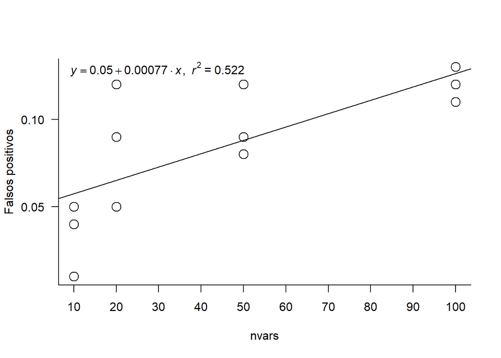

```r
par(bty='n')
plot(falsos_positivos ~ nvars, ylab = "Falsos positivos", xlab = expression(paste("nvars")),  cex = 1.75, axes = F, main = "")
axis(2, las = 1, seq(from = 0, to = 1, by = 0.05))
axis(1, seq(from = 0, to = 100, by = 10))
X1 <- grconvertX(0, "npc")
Y1 <- grconvertY(1, "npc")
legend(X1, Y1, bty = "n",
       cex = 1,legend = eq2, border = T, x.intersp = 0.1, y.intersp = 0.3, horiz = T)
box(bty = "l")
abline(relacion2)
```

# Figura de organismo no humano preferido

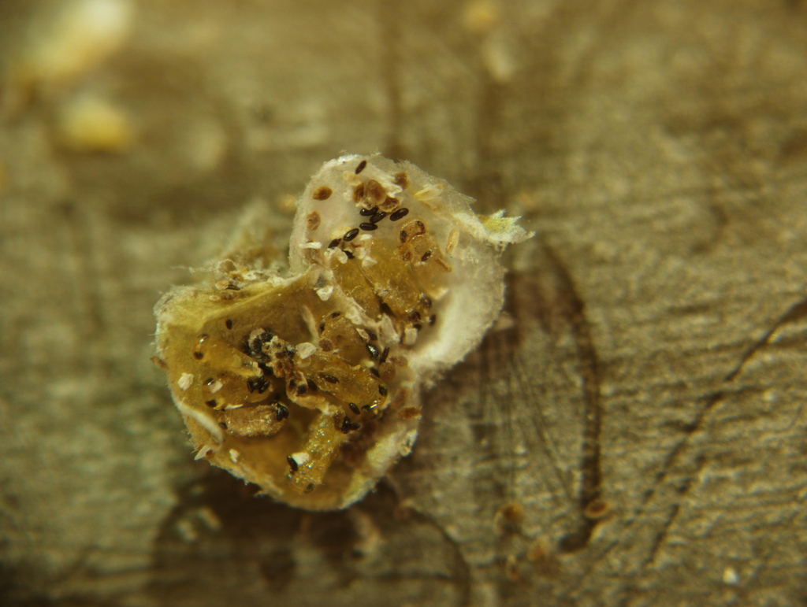

En la foto pupas de la Avispa *Aphytis* sp. parasitoide de la escama *Diaspis boisduvalii* en el cultivo de banano (*Musa* AAA) en Costa Rica. Tomada por M. Solano, 2018

Información de la sesión

```
## [1] "Windows 10 x64 (build 18362)"
```